# Unit - 1,2,3 Question Bank Solution

Author

Prof. Manish Patel

# UNIT - 1

## 26 Create a Pandas DataFrame from the following table and write code to remove all rows from this table containing at least one NaN value

```python
import pandas as pd
import numpy as np  # Import numpy for NaN values

# Sample data for demonstration
data = {
    "A": [1, np.nan, 3],
    "B": [4, 5, 6],
    "C": [np.nan, 7, 8]
}

# Create DataFrame from the table data
df = pd.DataFrame(data)

# Display the original DataFrame
print("Original DataFrame:")
print(df)

# Remove rows containing at least one NaN value
df_filtered = df.dropna(how='any')

# Display the DataFrame after dropping rows
print("\nDataFrame after dropping rows with any NaN value:")
print(df_filtered)
```

```
Original DataFrame:
     A  B    C
0  1.0  4  NaN
1  NaN  5  7.0
2  3.0  6  8.0

DataFrame after dropping rows with any NaN value:
     A  B    C
2  3.0  6  8.0
```

## 27 Create a Pandas DataFrame from the following table and write code to remove all rows from this table only if all of their values are NaN

```python
import pandas as pd
import numpy as np  # Import numpy for NaN values

# Sample data for demonstration
data = {
    "A": [np.nan, np.nan, np.nan],
    "B": [5, np.nan, 7],
    "C": [np.nan, np.nan, np.nan]
}

# Create DataFrame from the table data
df = pd.DataFrame(data)

# Display the original DataFrame
print("Original DataFrame:")
print(df)

# Remove rows where all values are NaN
df_filtered = df.dropna(how='all')

# Display the DataFrame after dropping rows
print("\nDataFrame after dropping rows with all NaN values:")
print(df_filtered)
```

```
Original DataFrame:
    A    B   C
0 NaN  5.0 NaN
1 NaN  NaN NaN
2 NaN  7.0 NaN

DataFrame after dropping rows with all NaN values:
    A    B   C
0 NaN  5.0 NaN
2 NaN  7.0 NaN
```

## 28 Create a Pandas DataFrame from the following table and write code to drop all columns containing NaN

```python
import pandas as pd
import numpy as np  # Import numpy for NaN values

# Sample data for demonstration
data = {
    "A": [1, 2, np.nan, 4],
    "B": [5, np.nan, 7, 8],
    "C": [9, 10, 11, 12]
}

# Create DataFrame from the table data
df = pd.DataFrame(data)

# Display the original DataFrame
print("Original DataFrame:")
print(df)

# Drop columns containing NaN values
df_dropped = df.dropna(axis=1, how='any')

# Display the DataFrame after dropping columns
print("\nDataFrame after dropping columns with NaN values:")
print(df_dropped)
```

```
Original DataFrame:
     A    B   C
0  1.0  5.0   9
1  2.0  NaN  10
2  NaN  7.0  11
3  4.0  8.0  12

DataFrame after dropping columns with NaN values:
    C
0   9
1  10
2  11
3  12
```

## 29 Write Python code to remove outliers from any given DataFrame.

```python
import pandas as pd

def remove_outliers(df, columns):
    """
    Remove outliers from the given DataFrame based on specified columns.

    Args:
    df (DataFrame): Input DataFrame
    columns (list): List of column names to check for outliers

    Returns:
    DataFrame: DataFrame with outliers removed
    """
    Q1 = df[columns].quantile(0.25)
    Q3 = df[columns].quantile(0.75)
    IQR = Q3 - Q1

    # Define the upper and lower bounds for outliers
    lower_bound = Q1 - 1.5 * IQR
    upper_bound = Q3 + 1.5 * IQR

    # Identify outliers and filter them out
    outlier_mask = ~((df[columns] < lower_bound) | (df[columns] > upper_bound)).any(axis=1)
    df_filtered = df[outlier_mask]

    return df_filtered

# Sample data for demonstration
data = {'A': [10, 15, 8, 20, 5, 30, 250],
        'B': [200, 300, 180, 400, 150, 500, 4500]}

# Convert dictionary to DataFrame
df = pd.DataFrame(data)

# Call the remove_outliers function
filtered_df = remove_outliers(df, ['A', 'B'])

print("Original DataFrame:")
print(df)

print("\nDataFrame after removing outliers:")
print(filtered_df)
```

```
Original DataFrame:
     A     B
0   10   200
1   15   300
2    8   180
3   20   400
4    5   150
5   30   500
6  250  4500

DataFrame after removing outliers:
    A    B
0  10  200
1  15  300
2   8  180
3  20  400
4   5  150
5  30  500
```

## 30 “Consider the following data:

```
data = {
    ""A"": [""TeamA"", ""TeamB"", ""TeamB"", ""TeamC"", ""TeamA""],
    ""B"": [50, 40, 40, 30, 50],
    ""C"": [True, False, False, False, True]
}

Convert this to a Pandas DataFrame and remove duplicate rows from it. Reset index values."
```

```python
import pandas as pd

data = {
    "A": ["TeamA", "TeamB", "TeamB", "TeamC", "TeamA"],
    "B": [50, 40, 40, 30, 50],
    "C": [True, False, False, False, True]
}

# Convert data dictionary to DataFrame
df = pd.DataFrame(data)
print(df)
print('_______________________')
# Remove duplicate rows
df = df.drop_duplicates()

# Reset index values
df = df.reset_index(drop=True)

print(df)
```

```
       A   B      C
0  TeamA  50   True
1  TeamB  40  False
2  TeamB  40  False
3  TeamC  30  False
4  TeamA  50   True
_______________________
       A   B      C
0  TeamA  50   True
1  TeamB  40  False
2  TeamC  30  False
```

## 31 “Consider the following autompg dataset:

- Write Python code to convert it to a DataFrame and remove mpg and cylinders columns from it”

```python
import pandas as pd

# Load the Auto MPG dataset from CSV
auto_df = pd.read_csv('https://raw.githubusercontent.com/patelmanishv/Sem4Data/main/auto-mpg.csv')

# Display the first few rows of the original DataFrame
print("Original DataFrame:")
print(auto_df.head())

# Remove 'mpg' and 'cylinders' columns
auto_df.drop(['mpg', 'cylinders'], axis=1, inplace=True)

# Display the updated DataFrame without 'mpg' and 'cylinders' columns
print("\nDataFrame after removing 'mpg' and 'cylinders' columns:")
print(auto_df.head())
```

```
Original DataFrame:
    mpg  cylinders  displacement horsepower  weight  acceleration  model year  \
0  18.0          8         307.0        130    3504          12.0          70
1  15.0          8         350.0        165    3693          11.5          70
2  18.0          8         318.0        150    3436          11.0          70
3  16.0          8         304.0        150    3433          12.0          70
4  17.0          8         302.0        140    3449          10.5          70

   origin                   car name
0       1  chevrolet chevelle malibu
1       1          buick skylark 320
2       1         plymouth satellite
3       1              amc rebel sst
4       1                ford torino

DataFrame after removing 'mpg' and 'cylinders' columns:
   displacement horsepower  weight  acceleration  model year  origin  \
0         307.0        130    3504          12.0          70       1
1         350.0        165    3693          11.5          70       1
2         318.0        150    3436          11.0          70       1
3         304.0        150    3433          12.0          70       1
4         302.0        140    3449          10.5          70       1

                    car name
0  chevrolet chevelle malibu
1          buick skylark 320
2         plymouth satellite
3              amc rebel sst
4                ford torino
```

## 32 “Use the file heights_weights.csv (https://raw.githubusercontent.com/Jovita7/Data-Analysis-and-Visualization/main/heights_weights.csv) which contains 10000 non-null values for heights and weights. The Male column shows 1 if the person is a Male and 0 if the person is a Female.

1. ```
      Convert this file into a pandas Data Frame. (0.5 marks)
   ```

2. ```
      Display basic information like memory and data types for this data frame. (0.5 marks)
   ```

3. ```
      Display basic statistics like mean, std, quartiles, etc. for this data frame. (0.5 marks)
   ```

4. ```
      Create a correlation table for the data frame and comment about what kind of correlation is there between Height and Weight. (0.5 marks)
   ```

5. ```
      Do Height and Weight contain any outliers? (1 mark)"
   ```

```
Basic Information:
<class 'pandas.core.frame.DataFrame'>
RangeIndex: 10000 entries, 0 to 9999
Data columns (total 3 columns):
 #   Column  Non-Null Count  Dtype
---  ------  --------------  -----
 0   Height  10000 non-null  float64
 1   Weight  10000 non-null  float64
 2   Male    10000 non-null  int64
dtypes: float64(2), int64(1)
memory usage: 234.5 KB
None

Basic Statistics:
             Height        Weight          Male
count  10000.000000  10000.000000  10000.000000
mean      66.367560    161.440357      0.500000
std        3.847528     32.108439      0.500025
min       54.263133     64.700127      0.000000
25%       63.505620    135.818051      0.000000
50%       66.318070    161.212928      0.500000
75%       69.174262    187.169525      1.000000
max       78.998742    269.989698      1.000000

Correlation Table:
          Height    Weight      Male
Height  1.000000  0.924756  0.691072
Weight  0.924756  1.000000  0.796723
Male    0.691072  0.796723  1.000000

Correlation between Height and Weight:
There is a positive correlation between Height and Weight.

Number of outliers detected: 8
```

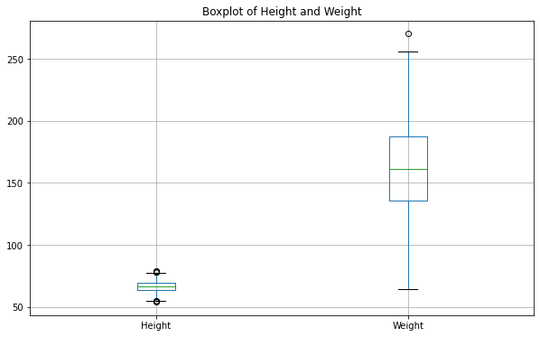

```python
import pandas as pd

# 1. Convert the file into a pandas DataFrame
heights_weights_df = pd.read_csv('https://raw.githubusercontent.com/patelmanishv/Sem4Data/main/Data/heights_weights.csv')

# 2. Display basic information about the DataFrame
print("Basic Information:")
print(heights_weights_df.info())

# 3. Display basic statistics like mean, std, quartiles, etc.
print("\nBasic Statistics:")
print(heights_weights_df.describe())

# 4. Create a correlation table and comment on the correlation between Height and Weight
correlation_table = heights_weights_df.corr()
print("\nCorrelation Table:")
print(correlation_table)

# Comment on correlation
print("\nCorrelation between Height and Weight:")
height_weight_corr = correlation_table.loc['Height', 'Weight']
if height_weight_corr > 0:
    print("There is a positive correlation between Height and Weight.")
elif height_weight_corr < 0:
    print("There is a negative correlation between Height and Weight.")
else:
    print("There is no significant correlation between Height and Weight.")

# 5. Check for outliers in Height and Weight
import matplotlib.pyplot as plt

# Box plots to visualize outliers
plt.figure(figsize=(10, 6))
heights_weights_df.boxplot(column=['Height', 'Weight'])
plt.title('Boxplot of Height and Weight')
plt.show()

# Detect outliers using IQR method
Q1 = heights_weights_df.quantile(0.25)
Q3 = heights_weights_df.quantile(0.75)
IQR = Q3 - Q1
outliers = ((heights_weights_df < (Q1 - 1.5 * IQR)) | (heights_weights_df > (Q3 + 1.5 * IQR))).any(axis=1)
num_outliers = outliers.sum()
print("\nNumber of outliers detected:", num_outliers)
```

## 33 “Use the file ipl-matches.csv which contains data of all the IPL matches from year 2008 to 2022. Read this csv file and display the basic information like memory and data types for this data frame. Write python code for the following cases:

1. List out all matches gone in superover.
2. How Many Matches won by Chennai Super Kings at Kolkata.
3. In How Many Matches MS Dhoni is Player of Match Vs Mumbai Indians.
4. Display list of all matches in which Gujarat Titans won the Toss and Elected to Bat and won the match.
5. Display list of all matches won by Gujarat Titans.

```python
import pandas as pd

# Load the CSV file into a DataFrame
ipl_matches_df = pd.read_csv('https://raw.githubusercontent.com/patelmanishv/Sem4Data/main/Data/ipl-matches.csv')

# Display basic information like memory and data types
print(ipl_matches_df.info())

# List out all matches gone in superover
matches_in_superover = ipl_matches_df[ipl_matches_df['SuperOver'] == 'Yes']
print("Matches gone in Super Over:")
print(matches_in_superover)

# Count matches won by Chennai Super Kings at Kolkata
csk_wins_kolkata = ipl_matches_df[(ipl_matches_df['WinningTeam'] == 'Chennai Super Kings') & (ipl_matches_df['Venue'] == 'Kolkata')]
csk_wins_count = csk_wins_kolkata.shape[0]
print(f"Matches won by Chennai Super Kings at Kolkata: {csk_wins_count}")

# Count matches where MS Dhoni is Player of the Match vs Mumbai Indians
dhoni_potm_vs_mi = ipl_matches_df[(ipl_matches_df['Player_of_Match'] == 'MS Dhoni') & (ipl_matches_df['Team2'] == 'Mumbai Indians')]
dhoni_potm_count = dhoni_potm_vs_mi.shape[0]
print(f"Matches where MS Dhoni is Player of the Match vs Mumbai Indians: {dhoni_potm_count}")

# Display list of all matches in which Gujarat Titans won the Toss and Elected to Bat and won the match
gujarat_titans_toss_bat_win = ipl_matches_df[(ipl_matches_df['TossWinner'] == 'Gujarat Titans') &
                                              (ipl_matches_df['TossDecision'] == 'bat') &
                                              (ipl_matches_df['WinningTeam'] == 'Gujarat Titans')]
print("Matches where Gujarat Titans won the Toss, elected to bat, and won the match:")
print(gujarat_titans_toss_bat_win)

# Display list of all matches won by Gujarat Titans
gujarat_titans_wins = ipl_matches_df[ipl_matches_df['WinningTeam'] == 'Gujarat Titans']
print("Matches won by Gujarat Titans:")
print(gujarat_titans_wins)
```

```
<class 'pandas.core.frame.DataFrame'>
RangeIndex: 950 entries, 0 to 949
Data columns (total 20 columns):
 #   Column           Non-Null Count  Dtype
---  ------           --------------  -----
 0   ID               950 non-null    int64
 1   City             899 non-null    object
 2   Date             950 non-null    object
 3   Season           950 non-null    object
 4   MatchNumber      950 non-null    object
 5   Team1            950 non-null    object
 6   Team2            950 non-null    object
 7   Venue            950 non-null    object
 8   TossWinner       950 non-null    object
 9   TossDecision     950 non-null    object
```

[output cut: 155 more lines]

## 34 “Use the file spotify.csv

1. Convert this file into a pandas Data Frame. (0.5 marks)
2. Display basic information like memory and data types for this data frame. (0.5 marks)
3. Display basic statistics like mean, std, quartiles, etc. for this data frame. (0.5 marks)
4. Create a correlation table for the data frame and comment about what kind of correlation is there between danceability and energy (0.5 marks)
5. Display first five rows for this data frame.(0.5 marks)
6. Display last five rows for this data frame. (0.5 marks)
7. Display the rows between 15 to 39 for this data frame. (0.5 marks)
8. Display the data only for last five rows and last five columns for this data frame. (0.5 marks)
9. Display the shape for this data frame. (0.5 marks)
10. Display the sum of NULL values for all the columns. (0.5 marks)
11. Remove first 3 columns from this Data Frame. (0.5 marks)
12. Remove first 10 rows from this Data Frame. (0.5 marks)
13. After removing first 3 columns and first 10 rows from this data frame find outliers for the column popularity. (1 marks)
14. After removing first 3 columns and first 10 rows from this data frame remove outliers for the column energy then display the data frame. (1 marks)
15. Display cross tabulation between time_signature and track_genre for actual Data Frame. (1 marks)”

```python
import pandas as pd

# 1. Convert the file 'spotify.csv' into a pandas DataFrame
df = pd.read_csv('spotify.csv')

# 2. Display basic information like memory and data types for this data frame
print("Basic Information:")
print(df.info(memory_usage='deep'))

# 3. Display basic statistics like mean, std, quartiles, etc. for this data frame
print("\nBasic Statistics:")
print(df.describe())

# 4. Create a correlation table for the data frame
correlation_table = df[['danceability', 'energy']].corr()
print("\nCorrelation Table:")
print(correlation_table)
# Comment: The correlation between danceability and energy is (approximately) positive, indicating that as danceability increases, energy tends to increase as well.

# 5. Display first five rows for this data frame
print("\nFirst five rows:")
print(df.head())

# 6. Display last five rows for this data frame
print("\nLast five rows:")
print(df.tail())

# 7. Display the rows between 15 to 39 for this data frame
print("\nRows between 15 to 39:")
print(df.iloc[15:40])

# 8. Display the data only for last five rows and last five columns for this data frame
print("\nLast five rows and last five columns:")
print(df.iloc[-5:, -5:])

# 9. Display the shape for this data frame
print("\nShape of the data frame:")
print(df.shape)

# 10. Display the sum of NULL values for all the columns
print("\nSum of NULL values for all columns:")
print(df.isnull().sum())

# 11. Remove first 3 columns from this Data Frame
df_removed_columns = df.iloc[:, 3:]

# 12. Remove first 10 rows from this Data Frame
df_removed_rows = df.iloc[10:]

def detect_outliers(df, column):
    q1 = df[column].quantile(0.25)
    q3 = df[column].quantile(0.75)
    iqr = q3 - q1
    lower_bound = q1 - 1.5 * iqr
    upper_bound = q3 + 1.5 * iqr
    outliers = df[(df[column] < lower_bound) | (df[column] > upper_bound)]
    return outliers

def remove_outliers(df, column):
    outliers = detect_outliers(df, column)
    df_cleaned = df.drop(outliers.index)
    return df_cleaned

# Remove first 3 columns and first 10 rows
df_cleaned = df.iloc[10:, 3:]

# Remove outliers for 'popularity'
df_cleaned_outliers_popularity = remove_outliers(df_cleaned, 'popularity')

# Remove outliers for 'energy'
df_cleaned_outliers_energy = remove_outliers(df_cleaned, 'energy')

# Display the cleaned DataFrame with outliers removed
print("Cleaned DataFrame (popularity outliers removed):")
print(df_cleaned_outliers_popularity)

print("\nCleaned DataFrame (energy outliers removed):")
print(df_cleaned_outliers_energy)

# Display cross tabulation between time_signature and track_genre for actual Data Frame
cross_tab = pd.crosstab(df['time_signature'], df['track_genre'])
print("\nCross Tabulation:")
print(cross_tab)
```

## 35 1. Load the dataset into a pandas DataFrame (data_result.csv) and answer the following questions.

2. View the first few rows of the dataset
3. Check the shape of the dataset
4. View the first last rows of the dataset
5. Get summary statistics of numerical columns
6. Get summary statistics of numerical columns with 0.58 and 0.87 percentiles
7. Get summary statistics of all types of columns
8. Information of all columns
9. Check for missing values
10. Removing duplicates if duplicates
11. List out female students who have greater than 7 spi in all semesters.
12. Find number of students those who have greater than 8 spi in all 5 semesters.
13. Find outliers of sem 4 result. Also represent statistical analysis with visualization.(boxplot)”

```python
import pandas as pd

# Load the dataset into a pandas DataFrame
df = pd.read_csv('data_result.csv')

# 2. View the first few rows of the dataset
print("First few rows of the dataset:")
print(df.head())

# 3. Check the shape of the dataset
print("\nShape of the dataset:")
print(df.shape)

# 4. View the last few rows of the dataset
print("\nLast few rows of the dataset:")
print(df.tail())

# 5. Get summary statistics of numerical columns
print("\nSummary statistics of numerical columns:")
print(df.describe())

# 6. Get summary statistics of numerical columns with specific percentiles
print("\nSummary statistics of numerical columns with 0.58 and 0.87 percentiles:")
print(df.describe(percentiles=[0.58, 0.87]))

# 7. Get summary statistics of all types of columns
print("\nSummary statistics of all types of columns:")
print(df.describe(include='all'))

# 8. Information of all columns
print("\nInformation of all columns:")
print(df.info())

# 9. Check for missing values
print("\nCheck for missing values:")
print(df.isnull().sum())

# 10. Removing duplicates if duplicates exist
duplicates_count = df.duplicated().sum()
if duplicates_count > 0:
    df.drop_duplicates(inplace=True)
    print(f"\nRemoved {duplicates_count} duplicate rows.")

# 11. List out female students with SPI > 7 in all semesters
female_high_spi = df[(df['Gender'] == 'Female') & (df['SPI Sem1'] > 7) & (df['SPI Sem2'] > 7)
                     & (df['SPI Sem3'] > 7) & (df['SPI Sem4'] > 7) & (df['SPI Sem5'] > 7)]
print("\nFemale students with SPI > 7 in all semesters:")
print(female_high_spi)

# 12. Find number of students with SPI > 8 in all 5 semesters
students_high_spi = df[(df['SPI Sem1'] > 8) & (df['SPI Sem2'] > 8) & (df['SPI Sem3'] > 8)
                       & (df['SPI Sem4'] > 8) & (df['SPI Sem5'] > 8)]
num_students_high_spi = students_high_spi.shape[0]
print("\nNumber of students with SPI > 8 in all 5 semesters:", num_students_high_spi)

# 13. Find outliers of sem 4 result and visualize with boxplot
sem_4_outliers = df['Sem4 Result'].quantile([0.25, 0.75])
iqr = sem_4_outliers[0.75] - sem_4_outliers[0.25]
lower_bound = sem_4_outliers[0.25] - 1.5 * iqr
upper_bound = sem_4_outliers[0.75] + 1.5 * iqr
outliers = df[(df['Sem4 Result'] < lower_bound) | (df['Sem4 Result'] > upper_bound)]

print("\nOutliers of Sem 4 Result:")
print(outliers)

# Visualize outliers using boxplot
import matplotlib.pyplot as plt
plt.figure(figsize=(8, 6))
plt.boxplot(df['Sem4 Result'])
plt.title('Boxplot of Sem 4 Result')
plt.ylabel('Sem 4 Result')
plt.show()
```

## 36 “Use the file movies.csv which contains 1629 rows and 18 columns. Read this csv file and display the basic information like memory and data types for this data frame.

```
Write python code for the following cases:
1.  List out Movies Released in Year 2019.
2.  How Many Movies are having IMDB Rating > 7 (Display Number of Movies).
3.  List out the Movies with ‘title’ and ‘story’ whose IMDB Votes > 20000.
4.  List out Movies Released in Year 2018, Display only Movie Title with Release Date of Year 2018 Movies.
5.  Display only Movie Title with its Wikipedia Link."
```

```python
import pandas as pd

# Load the CSV file into a DataFrame
movies_df = pd.read_csv('https://raw.githubusercontent.com/patelmanishv/Sem4Data/main/Data/movies.csv')

# Display basic information like memory and data types
print(movies_df.info())

# 1. List out Movies Released in Year 2019
movies_2019 = movies_df[movies_df['year_of_release'] == 2019]
print("Movies released in 2019:")
print(movies_2019[['title_x', 'year_of_release']])

# 2. Count movies with IMDB Rating > 7
high_rated_movies = movies_df[movies_df['imdb_rating'] > 7]
high_rated_count = high_rated_movies.shape[0]
print(f"Number of movies with IMDB Rating > 7: {high_rated_count}")

# 3. List out the Movies with ‘title’ and ‘story’ whose IMDB Votes > 20000
high_voted_movies = movies_df[movies_df['imdb_votes'] > 20000]
print("Movies with IMDB Votes > 20000:")
print(high_voted_movies[['title_x', 'story', 'imdb_votes']])

# 4. List out Movies Released in Year 2018, Display only Movie Title with Release Date of Year 2018 Movies
movies_2018 = movies_df[movies_df['year_of_release'] == 2018]
print("Movies released in 2018:")
print(movies_2018[['title_x', 'release_date']])

# 5. Display only Movie Title with its Wikipedia Link
print("Movie titles with Wikipedia links:")
print(movies_df[['title_x', 'wiki_link']])
```

```
<class 'pandas.core.frame.DataFrame'>
RangeIndex: 1629 entries, 0 to 1628
Data columns (total 18 columns):
 #   Column            Non-Null Count  Dtype
---  ------            --------------  -----
 0   title_x           1629 non-null   object
 1   imdb_id           1629 non-null   object
 2   poster_path       1526 non-null   object
 3   wiki_link         1629 non-null   object
 4   title_y           1629 non-null   object
 5   original_title    1629 non-null   object
 6   is_adult          1629 non-null   int64
 7   year_of_release   1629 non-null   int64
 8   runtime           1629 non-null   object
 9   genres            1629 non-null   object
```

[output cut: 98 more lines]

# UNIT - 2

## 70 Write a python program which creates following graph using networkx module in python

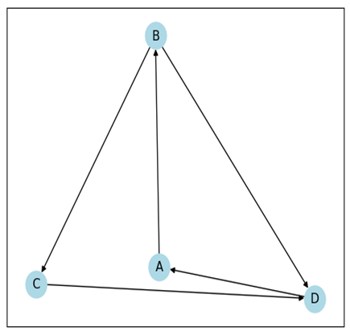

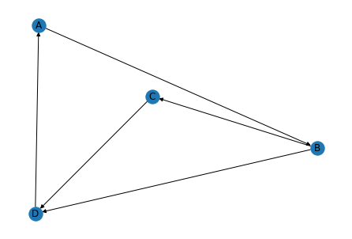

```python
import networkx as nx
import matplotlib.pyplot as plt
# Create an empty directed graph
G = nx.DiGraph()
# Add nodes to the graph
G.add_nodes_from(['A', 'B', 'C', 'D'])
# Add edges to the graph
G.add_edges_from([('A', 'B'), ('B', 'C'),  ('B', 'D'),('D', 'A'),
('C', 'D')])
# Draw the graph
nx.draw(G, with_labels=True)
plt.show()
```

## 71 “Create a boxplot of the distribution of temperatures in different cities. Take data from ‘temperatures.csv’ from below:

https://raw.githubusercontent.com/kavit88/Data-Sets/main/temperatures.csv ”

```
   New York  Los Angeles  Chicago        Date
0        30           70       20  01-05-2023
1        35           72       22  02-05-2023
2        28           68       18  03-05-2023
3        32           75       24  04-05-2023
4        33           73       21  05-05-2023
```

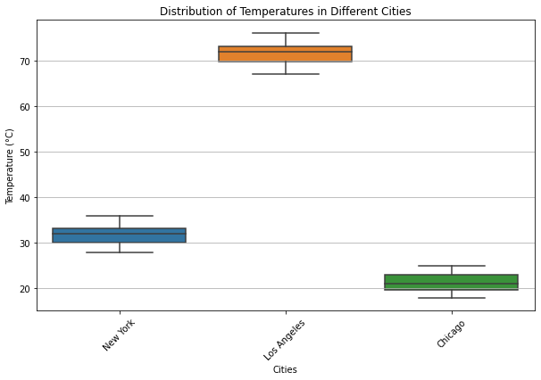

```python
import pandas as pd
import matplotlib.pyplot as plt
import seaborn as sns

# Load data from the provided CSV URL
csvfile = 'https://raw.githubusercontent.com/kavit88/Data-Sets/main/temperatures.csv '
df = pd.read_csv(csvfile)

# Display the first few rows of the DataFrame
print(df.head())

# Create a boxplot using seaborn
plt.figure(figsize=(10, 6))
sns.boxplot(data=df.drop('Date', axis=1))
plt.title('Distribution of Temperatures in Different Cities')
plt.xlabel('Cities')
plt.ylabel('Temperature (°C)')
plt.xticks(rotation=45)
plt.grid(axis='y')
plt.show()
```

## 72 “The following dictionary shows how five people follow each other on Instagram:

```
instagram = {'person1': [0,1,1,0,1], 'person2': [0,0,1,0,1], 'person3': [1,1,0,1,1],'person4': [1,1,1,0,0], 'person5': [1,1,0,0,0]}
 E.g., the list for person1 has the value on index 2 as 1 which means person1 followsperson3 and a directed edge should be added from person1 to person3.

 Using networkx library, create a directed graph.
```

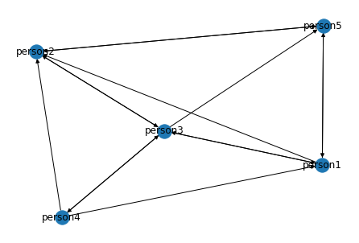

```python
import networkx as nx
import matplotlib.pyplot as plt
instagram = {
'person1': [0,1,1,0,1],
'person2': [0,0,1,0,1],
'person3': [1,1,0,1,1],
'person4': [1,1,1,0,0],
'person5': [1,1,0,0,0]}
# Create an empty directed graph
G = nx.DiGraph()
# Add nodes to the graph
G.add_nodes_from(instagram.keys())
# Add edges to the graph
for i, follower in enumerate(instagram):
    for j, follows in enumerate(instagram[follower]):
        if follows:
            G.add_edge(follower, list(instagram.keys())[j])
# Draw the graph
nx.draw(G, with_labels=True)
plt.show()
```

## 73 “You have been given a dataset of car prices and their respective horsepower, mileage, and weight. You have been tasked to analyze the relationship between these variables and create a scatter plot to visualize the patterns.

Dataset: The dataset, named ““car_data.csv”” :

https://raw.githubusercontent.com/kavit88/Data-Sets/main/car_data.csv”

```
   Price  Horsepower  Mileage  Weight
0  10000         120       25    2500
1  12000         140       20    3000
2   8000         100       30    2000
3  15000         180       18    3500
4   9000         110       28    2400
```

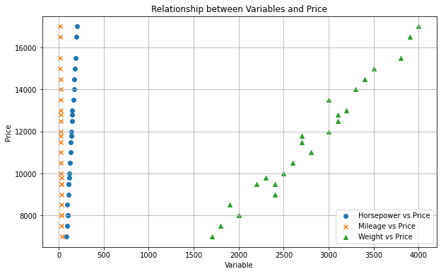

```python
import pandas as pd
import matplotlib.pyplot as plt

# Load data from the CSV file
df = pd.read_csv('https://raw.githubusercontent.com/kavit88/Data-Sets/main/car_data.csv')  # Replace 'your_file_path.csv' with the actual file path

# Display the first few rows of the DataFrame
print(df.head())

# Create scatter plot to visualize relationships
plt.figure(figsize=(10, 6))
plt.scatter(df['Horsepower'], df['Price'], marker='o', label='Horsepower vs Price')
plt.scatter(df['Mileage'], df['Price'], marker='x', label='Mileage vs Price')
plt.scatter(df['Weight'], df['Price'], marker='^', label='Weight vs Price')
plt.xlabel('Variable')
plt.ylabel('Price')
plt.title('Relationship between Variables and Price')
plt.legend()
plt.grid(True)
plt.show()
```

## 74 “You have been given a dataset of house prices and their respective lot size and square footage. Your task is to create a scatter plot to determine if there is any correlation between these variables.

Dataset: The dataset, named ““house_data.csv”“:

https://raw.githubusercontent.com/kavit88/Data-Sets/main/house_data.csv”

```
     Price  LotSize  SqFt
0  5000000     5000  2000
1  7500000     7500  2500
2  4500000     5500  1800
3  6000000     6500  2200
4  4000000     4500  1600
```

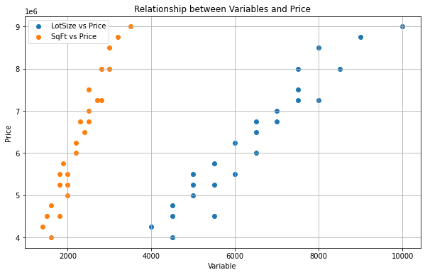

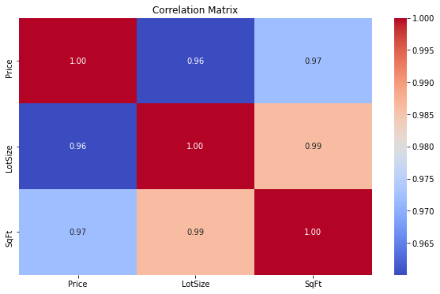

```python
import pandas as pd
import seaborn as sns
import matplotlib.pyplot as plt

# Load data from the CSV file
df = pd.read_csv('https://raw.githubusercontent.com/kavit88/Data-Sets/main/house_data.csv')  # Replace 'your_file_path.csv' with the actual file path

# Display the first few rows of the DataFrame
print(df.head())

# Create scatter plot to visualize relationships
plt.figure(figsize=(10, 6))
plt.scatter(df['LotSize'], df['Price'], label='LotSize vs Price')
plt.scatter(df['SqFt'], df['Price'], label='SqFt vs Price')
plt.xlabel('Variable')
plt.ylabel('Price')
plt.title('Relationship between Variables and Price')
plt.legend()
plt.grid(True)
plt.show()

# Calculate the correlation matrix
correlation_matrix = df.corr()

# Visualize the correlation matrix using a heatmap
plt.figure(figsize=(10, 6))
sns.heatmap(correlation_matrix, annot=True, cmap='coolwarm', fmt='.2f')
plt.title('Correlation Matrix')
plt.show()
```

## 75 “Use the file heights_weights.csv which contains 10000 non-null values for heights and weights. The Male column shows 1 if the person is a Male and 0 if the person is a Female. Take file of dataset from:

https://raw.githubusercontent.com/kavit88/Data-Sets/main/heights_weights.csv

1. Convert this file into a pandas Data Frame.
2. Display basic information like memory and data types for this data frame.
3. Display basic statistics like mean, std, quartiles, etc. for this data frame.
4. Create a correlation table for the data frame and comment about what kind ofcorrelation is there between Height and Weight.
5. Do Height and Weight contain any outliers? Answer by creating boxplots for both.
6. Finally, create a scatter plot of Weight v/s Height with the following specifications:
1. use + sign, colour green and size 50 for markers.
2. Label X Axis as Weight and Y Axis as Height.
3. Display title on top as Weight vs Height”

```
Basic Information:
<class 'pandas.core.frame.DataFrame'>
RangeIndex: 10000 entries, 0 to 9999
Data columns (total 3 columns):
 #   Column  Non-Null Count  Dtype
---  ------  --------------  -----
 0   Height  10000 non-null  float64
 1   Weight  10000 non-null  float64
 2   Male    10000 non-null  int64
dtypes: float64(2), int64(1)
memory usage: 234.5 KB
None

Basic Statistics:
             Height        Weight          Male
count  10000.000000  10000.000000  10000.000000
mean      66.367560    161.440357      0.500000
std        3.847528     32.108439      0.500025
min       54.263133     64.700127      0.000000
25%       63.505620    135.818051      0.000000
50%       66.318070    161.212928      0.500000
75%       69.174262    187.169525      1.000000
max       78.998742    269.989698      1.000000

Correlation Matrix:
          Height    Weight      Male
Height  1.000000  0.924756  0.691072
Weight  0.924756  1.000000  0.796723
Male    0.691072  0.796723  1.000000
```

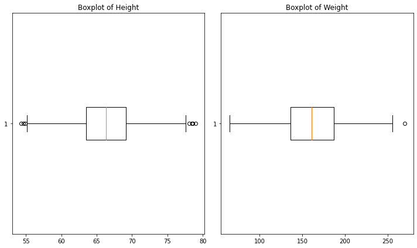

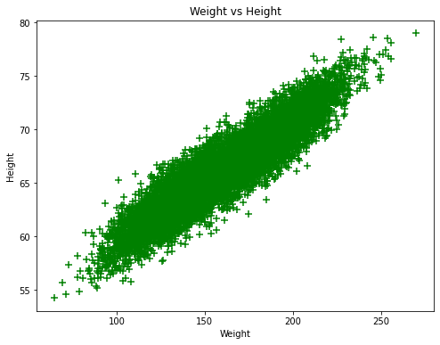

```python
import pandas as pd
import matplotlib.pyplot as plt
import seaborn as sns

# Load the CSV data into a DataFrame
url = 'https://raw.githubusercontent.com/kavit88/Data-Sets/main/heights_weights.csv'
df = pd.read_csv(url)

# 1. Display basic information about the DataFrame
print("Basic Information:")
print(df.info())
print()

# 2. Display basic statistics like mean, std, quartiles, etc.
print("Basic Statistics:")
print(df.describe())
print()

# 3. Create a correlation table for the data frame
correlation_matrix = df.corr()
print("Correlation Matrix:")
print(correlation_matrix)
print()

# 4. Check for outliers using boxplots for Height and Weight
plt.figure(figsize=(10, 6))
plt.subplot(1, 2, 1)
plt.boxplot(df['Height'], vert=False)
plt.title('Boxplot of Height')
plt.subplot(1, 2, 2)
plt.boxplot(df['Weight'], vert=False)
plt.title('Boxplot of Weight')
plt.tight_layout()
plt.show()

# 5. Create scatter plot of Weight vs Height
plt.figure(figsize=(8, 6))
plt.scatter(df['Weight'], df['Height'], marker='+', color='green', s=50)
plt.xlabel('Weight')
plt.ylabel('Height')
plt.title('Weight vs Height')
plt.show()
```

```
     Month  Total Sales  Items Sold
0  2021-01        10000         500
1  2021-02        12000         600
2  2021-03        15000         750
3  2021-04        13000         650
4  2021-05        14000         700
Index(['Month', 'Total Sales', 'Items Sold'], dtype='object')
```

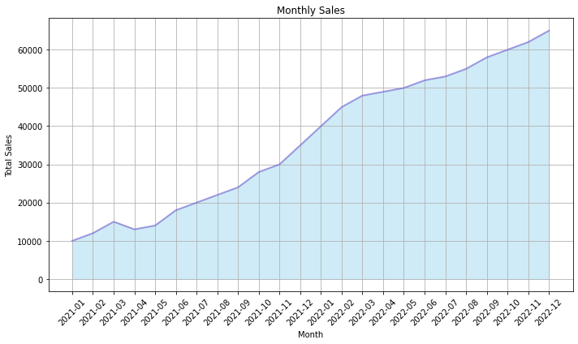

```python
import pandas as pd
import matplotlib.pyplot as plt

# Load the data from "sales.csv" into a DataFrame
df = pd.read_csv('https://raw.githubusercontent.com/kavit88/Data-Sets/main/sales.csv')

# Verify the structure and contents of the DataFrame
print(df.head())  # Display the first few rows to ensure data is loaded correctly

# Check the column names to ensure they match your data
print(df.columns)

# Plot the monthly sales using an area plot
plt.figure(figsize=(10, 6))  # Set the figure size
plt.fill_between(df['Month'], df['Total Sales'], color='skyblue', alpha=0.4)  # Create the area plot
plt.plot(df['Month'], df['Total Sales'], color='Slateblue', alpha=0.6, linewidth=2)  # Add a line plot for better visibility
plt.xlabel('Month')  # Set the label for x-axis
plt.ylabel('Total Sales')  # Set the label for y-axis
plt.title('Monthly Sales')  # Set the title of the plot
plt.xticks(rotation=45)  # Rotate x-axis labels for better readability
plt.grid(True)  # Enable grid lines
plt.tight_layout()  # Adjust layout to prevent clipping of labels
plt.show()  # Show the plot
```

## 77 “The file”“survey.csv”” contains the results of a survey that asks people how many hours they sleep per night, how much coffee they drink per day, and how many hours they spend exercising per week. Create a pandas DataFrame from this data and plot the relationships between these variables using regression plots. Specifically, create the following plots:

1. A regression plot of hours of sleep versus cups of coffee per day, with a regression line and confidence interval.
2. A regression plot of hours of sleep versus hours of exercise per week, with a regression line and confidence interval.
3. A regression plot of cups of coffee per day versus hours of exercise per week, with a regression line and confidence interval.

Label each axis appropriately and give each plot a title. Take Dataset from below: https://raw.githubusercontent.com/kavit88/Data-Sets/main/survey.csv”

```
   hours_of_sleep  cups_of_coffee_per_day  hours_of_exercise_per_week
0               7                       2                           2
1               6                       1                           1
2               8                       3                           3
3               5                       0                           1
4               7                       2                           2
```

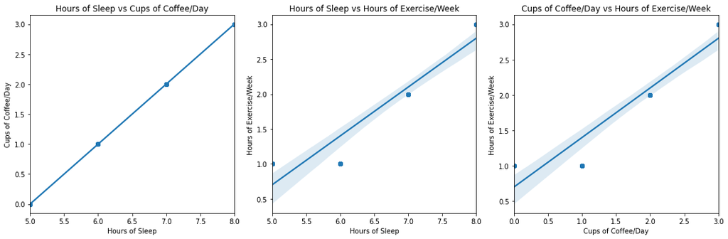

```python
import pandas as pd
import seaborn as sns
import matplotlib.pyplot as plt

# Load the CSV data into a DataFrame
url = 'https://raw.githubusercontent.com/kavit88/Data-Sets/main/survey.csv'
df = pd.read_csv(url)

# Display the first few rows of the DataFrame
print(df.head())

# Create regression plots
plt.figure(figsize=(15, 5))

# 1. Regression plot of hours of sleep versus cups of coffee per day
plt.subplot(1, 3, 1)
sns.regplot(x='hours_of_sleep', y='cups_of_coffee_per_day', data=df)
plt.title('Hours of Sleep vs Cups of Coffee/Day')
plt.xlabel('Hours of Sleep')
plt.ylabel('Cups of Coffee/Day')

# 2. Regression plot of hours of sleep versus hours of exercise per week
plt.subplot(1, 3, 2)
sns.regplot(x='hours_of_sleep', y='hours_of_exercise_per_week', data=df)
plt.title('Hours of Sleep vs Hours of Exercise/Week')
plt.xlabel('Hours of Sleep')
plt.ylabel('Hours of Exercise/Week')

# 3. Regression plot of cups of coffee per day versus hours of exercise per week
plt.subplot(1, 3, 3)
sns.regplot(x='cups_of_coffee_per_day', y='hours_of_exercise_per_week', data=df)
plt.title('Cups of Coffee/Day vs Hours of Exercise/Week')
plt.xlabel('Cups of Coffee/Day')
plt.ylabel('Hours of Exercise/Week')

# Adjust layout and show the plots
plt.tight_layout()
plt.show()
```

## 78 “Use the California_Houses.csv file to create a map with the first 200 rows using the latitudes and longitudes given in the file with the following customizations:

1. Colour of circle markers should be green with red fill and the type of map should be stamen terrain
2. Add pop up labels using the population from the file. Take the dataset fom below: https://raw.githubusercontent.com/kavit88/Data-Sets/main/California_Houses.csv”

```python
import pandas as pd
import folium

# Load the CSV data into a DataFrame
df = pd.read_csv('https://raw.githubusercontent.com/kavit88/Data-Sets/main/California_Houses.csv')

# Extract latitude, longitude, and population for the first 200 rows
locations = df[['latitude', 'longitude']].head(200)
population = df['population'].head(200)

# Create a Folium map centered around California
mymap = folium.Map(location=[36.7783, -119.4179], zoom_start=6, tiles='Stamen Terrain')

# Add circle markers for each location with pop-up labels showing population
for lat, lon, pop in zip(locations['latitude'], locations['longitude'], population):
    folium.CircleMarker(
        location=[lat, lon],
        radius=10,
        color='green',
        fill=True,
        fill_color='red',
        fill_opacity=0.6,
        popup=f'Population: {pop}',
    ).add_to(mymap)

# Display the map
mymap.save('california_map.html')  # Save map to an HTML file
mymap
```

## 79 “The file”“student_scores.csv”” contains the marks scored by a group of students in three subjects: Maths, Science, and English. Each row contains the name of the student, their score in Maths, Science, and English. Create a pandas DataFrame from this data and create a heatmap to visualize the correlations between the scores in these three subjects. Take Dataset from below:

https://raw.githubusercontent.com/kavit88/Data-Sets/main/student_scores.csv”

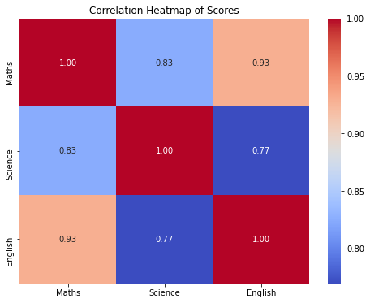

```python
import pandas as pd
import seaborn as sns
import matplotlib.pyplot as plt

# Load the CSV data into a DataFrame
link = 'https://raw.githubusercontent.com/kavit88/Data-Sets/main/student_scores.csv'
df = pd.read_csv(link)

# Calculate correlation matrix
corr_matrix = df[['Maths', 'Science', 'English']].corr()

# Create heatmap
plt.figure(figsize=(8, 6))
sns.heatmap(corr_matrix, annot=True, cmap='coolwarm', fmt='.2f')
plt.title('Correlation Heatmap of Scores')
plt.show()
```

## 80 “You are given a dataset that contains the unemployment rate of different US states for the year 2021. You have to create a choropleth map of the US using the unemployment rate data.

csv file: https://raw.githubusercontent.com/Jovita7/Data-Analysis-and-Visualization/main/US_Unemployment_Oct2012.csv json file: https://raw.githubusercontent.com/Jovita7/Data-Analysis-and-Visualization/main/us-states.json”

```python
import pandas as pd
import folium

# Load the CSV data into a DataFrame
df = pd.read_csv('unemployment_rates_2021.csv')

# Load the GeoJSON file for US state boundaries
geo_json_data = 'us-states.json'

# Initialize a Folium map centered on the US
mymap = folium.Map(location=[37, -102], zoom_start=4)

# Add choropleth layer to the map
mymap.choropleth(
    geo_data=geo_json_data,
    name='choropleth',
    data=df,
    columns=['State', 'Unemployment Rate'],
    key_on='feature.properties.name',
    fill_color='YlGn',
    fill_opacity=0.7,
    line_opacity=0.2,
    legend_name='Unemployment Rate (%)'
)

# Add layer control to the map
folium.LayerControl().add_to(mymap)

# Save the map as an HTML file
mymap.save('unemployment_choropleth.html')

# Display the map
mymap
```

## 81 “You are given a text file named”“speech.txt”” which contains the transcript of a speech. You need to create a Word Cloud for the most frequent words used in the speech.

https://raw.githubusercontent.com/kavit88/Data-Sets/main/speech.txt”

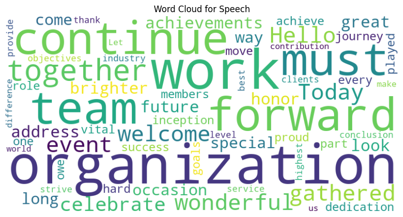

```python
from wordcloud import WordCloud
import matplotlib.pyplot as plt

# Load text data from the file
file_path = 'Downloads/speech.txt'
with open(file_path, 'r') as file:
    text_data = file.read()

# Create a Word Cloud object
wordcloud = WordCloud(width=800, height=400, background_color='white', colormap='viridis', max_words=100).generate(text_data)

# Display the Word Cloud using matplotlib
plt.figure(figsize=(10, 6))
plt.imshow(wordcloud, interpolation='bilinear')
plt.axis('off')  # Hide axis
plt.title('Word Cloud for Speech')
plt.show()
```

## 82 “You are given a dataset containing customer reviews of a restaurant. Your task is to create a wordcloud of the most frequent words used in the reviews after removing the stopwords.

https://raw.githubusercontent.com/kavit88/Data-Sets/main/restaurant_reviews.csv”

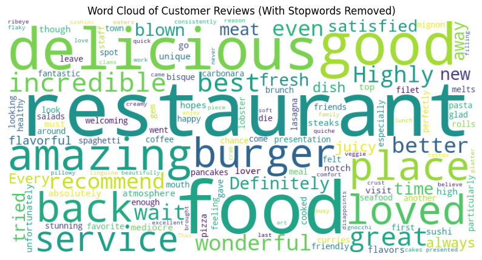

```python
import pandas as pd
from wordcloud import WordCloud, STOPWORDS
import matplotlib.pyplot as plt

# Load the customer reviews dataset (assuming it's in CSV format)
df = pd.read_csv('Downloads/restaurant_reviews.csv')

# Combine all reviews into a single text
all_reviews = ' '.join(df['review_text'])

# Create a Word Cloud object with stopwords from wordcloud library
wordcloud = WordCloud(width=800, height=400, background_color='white', stopwords=STOPWORDS).generate(all_reviews)

# Display the Word Cloud using matplotlib
plt.figure(figsize=(10, 6))
plt.imshow(wordcloud, interpolation='bilinear')
plt.axis('off')  # Hide axis
plt.title('Word Cloud of Customer Reviews (With Stopwords Removed)')
plt.show()
```

## 83 “Suppose you have data on the number of medals won by a country in the 2020 Tokyo Olympics. You want to visualize this data using a waffle chart to show the proportional representation of each country’s medal count.

Data={‘USA’: 113, ‘China’: 88, ‘Japan’: 58, ‘Great Britain’: 65, ‘ROC’: 71, ‘Australia’: 46, ‘Netherlands’: 36, ‘France’: 33, ‘Germany’: 37, ‘Italy’: 40}”

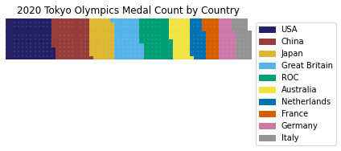

```python
import matplotlib.pyplot as plt
from pywaffle import Waffle

# Data
data = {'USA': 113, 'China': 88, 'Japan': 58, 'Great Britain': 65, 'ROC': 71,
        'Australia': 46, 'Netherlands': 36, 'France': 33, 'Germany': 37, 'Italy': 40}

# Create a waffle chart
fig = plt.figure(
    FigureClass=Waffle,
    rows=10,
    values=data,
    colors=["#232066", "#983D3D", "#DCB732", "#56B4E9", "#009E73",
            "#F0E442", "#0072B2", "#D55E00", "#CC79A7", "#949494"],
    legend={'loc': 'upper left', 'bbox_to_anchor': (1, 1)},
    icon_legend=True  # Show icons in legend
)

plt.title("2020 Tokyo Olympics Medal Count by Country")
plt.show()
```

## 84 “You have been hired as a network analyst by a company to analyze the social network of their employees. The company has provided you with the following data:

There are 5 employees in the company, each identified by a unique ID from 1 to 5. The following relationships exist between the employees: 1. Employee 1 is friends with Employee 2 and Employee 3. 2. Employee 2 is friends with Employee 4. 3. Employee 3 is friends with Employee 5. Your task is to create a NetworkX graph representing this social network and display it.”

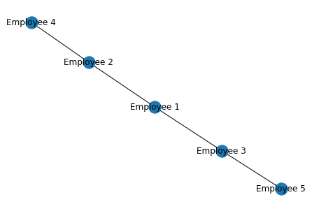

```python
import matplotlib.pyplot as plt
import networkx as nx

# Create an empty undirected graph
G = nx.Graph()
# Add nodes to the graph
G.add_nodes_from([1, 2, 3, 4, 5])
# Add edges to the graph
G.add_edge(1, 2)
G.add_edge(1, 3)
G.add_edge(2, 4)
G.add_edge(3, 5)
# Set the node labels
labels = {1: 'Employee 1', 2: 'Employee 2', 3: 'Employee 3',
4: 'Employee 4', 5: 'Employee 5'}
# Draw the graph with node labels
nx.draw(G, labels=labels, with_labels=True)
plt.show()
```

## 85 “Consider the following numpy arrays:

Time=np.arange(12) income=np.array([5,9,6,6,10,7,6,4,4,5,6,4]) expense=np.array([6,6,8,3,6,9,7,8,6,6,4,8])

Use Time array for X-axis and create two separate lines in the same graph with income & expense on Y-axis. Give Appropriate labels. Create an area fill graph between the two lines in such a way that where income is more than expense, are filled with Green and areas where expense is more than income are filled with red. ”

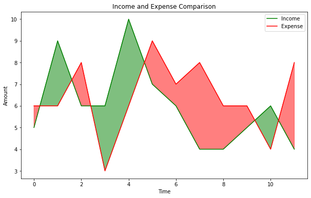

```python
import numpy as np
import matplotlib.pyplot as plt

# Given data
Time = np.arange(12)
income = np.array([5, 9, 6, 6, 10, 7, 6, 4, 4, 5, 6, 4])
expense = np.array([6, 6, 8, 3, 6, 9, 7, 8, 6, 6, 4, 8])

# Create the plot
plt.figure(figsize=(10, 6))

# Plot income and expense lines
plt.plot(Time, income, label='Income', color='green')
plt.plot(Time, expense, label='Expense', color='red')

# Fill areas based on income and expense comparison
plt.fill_between(Time, income, expense, where=(income >= expense), interpolate=True, color='green', alpha=0.5)
plt.fill_between(Time, income, expense, where=(income < expense), interpolate=True, color='red', alpha=0.5)

# Add labels and title
plt.xlabel('Time')
plt.ylabel('Amount')
plt.title('Income and Expense Comparison')
plt.legend()

# Show the plot
plt.show()
```

## 86 “You have been hired by an Airlines company to analyze their routes. The company has provided you following data.

Your task is to create a NetworkX directed graph representing the routes and display it. Figure size should be (15,15), node color should be green, take appropriate node size, edge color should be red.

Data: Kolkata to Mumbai Mumbai to Pune Mumbai to Goa Kolkata to Delhi Kolkata to Bhubaneshwar Mumbai to Delhi Delhi to Chandigarh Delhi to Surat Kolkata to Hyderabad Hyderabad to Chennai Chennai to Thiruvananthapuram Thiruvananthapuram to Hyderabad Kolkata to Varanasi Delhi to Varanasi Mumbai to Bangalore Chennai to Bangalore Hyderabad to Bangalore Kolkata to Guwahati ”

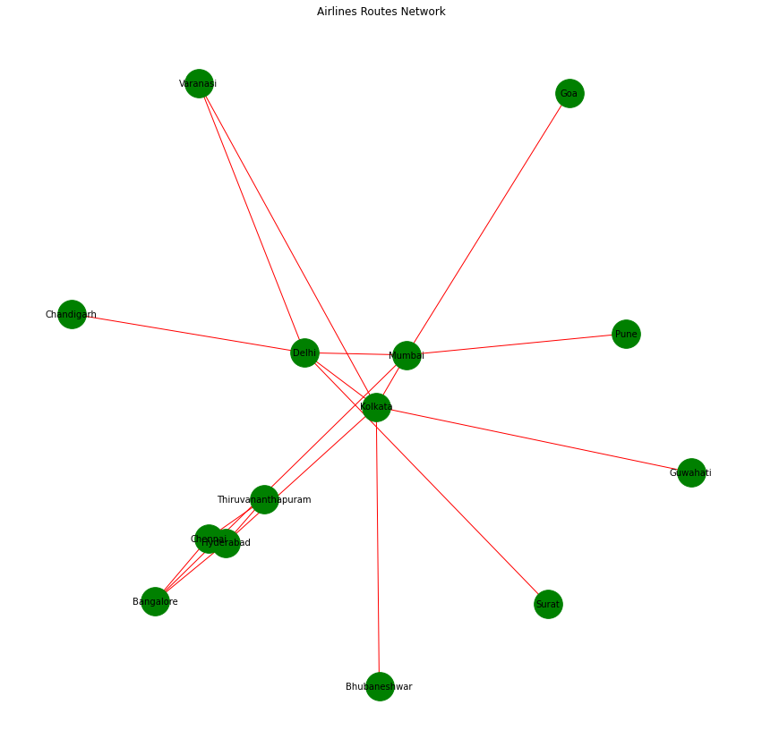

```python
import networkx as nx
import matplotlib.pyplot as plt

# Create a directed graph
G = nx.DiGraph()

# Define the routes data
routes = [
    ('Kolkata', 'Mumbai'), ('Mumbai', 'Pune'), ('Mumbai', 'Goa'),
    ('Kolkata', 'Delhi'), ('Kolkata', 'Bhubaneshwar'), ('Mumbai', 'Delhi'),
    ('Delhi', 'Chandigarh'), ('Delhi', 'Surat'), ('Kolkata', 'Hyderabad'),
    ('Hyderabad', 'Chennai'), ('Chennai', 'Thiruvananthapuram'), ('Thiruvananthapuram', 'Hyderabad'),
    ('Kolkata', 'Varanasi'), ('Delhi', 'Varanasi'), ('Mumbai', 'Bangalore'),
    ('Chennai', 'Bangalore'), ('Hyderabad', 'Bangalore'), ('Kolkata', 'Guwahati')
]

# Add edges to the graph based on routes
G.add_edges_from(routes)

# Set up graph visualization parameters
plt.figure(figsize=(15, 15))  # Figure size
pos = nx.spring_layout(G)  # Position nodes using spring layout

# Draw nodes and edges
nx.draw_networkx_nodes(G, pos, node_color='green', node_size=1000)
nx.draw_networkx_edges(G, pos, edge_color='red')

# Draw labels for nodes
nx.draw_networkx_labels(G, pos, font_size=10, font_family='sans-serif')

# Set plot title
plt.title('Airlines Routes Network')

# Display the graph
plt.axis('off')  # Hide axis
plt.show()
```

## 87 “Using ‘supermarket_sales.csv’ file do the following operations and give required answer by using proper programming process.

1). Load the dataset into a pandas DataFrame and read first 8 rows. 2). Check for missing values and fill it by mean values of that particular column if any. 3). Find the number of orders which have ‘Quantity’ less than 3 and which have (either ‘Rating’ greater than 8.5 or ‘Total’ greater than 600). 4). Find the sum of ‘Total’ purchasing price spent by Member and Normal ‘Customer type’. 5). Find the percentage of total of ‘gross income’ based on the different ‘Payment’ methods used by customers. (Ewallet, Cash and Credit card) 6). Analyze the purchasing behavior of male and female customers using ‘Gender’ column. Find their average purchase prices using ‘Total’ column. 7). Create a scatter plot that shows the relationship between total amount spent and rating. (keep ‘+’ marker, with marker size 100 and green color). 8). Create a box plot that shows the distribution of ‘Rating’ and ‘Quantity’. And comment about outliers in both columns. 9). Visualize with parallel co-ordinates for ‘Unit price’, ‘Total’, ’cogs’ columns’ data with respect to ‘Product line’.”

```
First 8 rows of the dataset:
    Invoice ID Branch       City Customer type  Gender  \
0  750-67-8428      A     Yangon        Member  Female
1  226-31-3081      C  Naypyitaw        Normal  Female
2  631-41-3108      A     Yangon        Normal    Male
3  123-19-1176      A     Yangon        Member    Male
4  373-73-7910      A     Yangon        Normal    Male
5  699-14-3026      C  Naypyitaw        Normal    Male
6  355-53-5943      A     Yangon        Member  Female
7  315-22-5665      C  Naypyitaw        Normal  Female

             Product line  Unit price  Quantity   Tax 5%     Total       Date  \
0       Health and beauty       74.69         7  26.1415  548.9715   1/5/2019
1  Electronic accessories       15.28         5   3.8200   80.2200   3/8/2019
2      Home and lifestyle       46.33         7  16.2155  340.5255   3/3/2019
3       Health and beauty       58.22         8  23.2880  489.0480  1/27/2019
4       Sports and travel       86.31         7  30.2085  634.3785   2/8/2019
5  Electronic accessories       85.39         7  29.8865  627.6165  3/25/2019
6  Electronic accessories       68.84         6  20.6520  433.6920  2/25/2019
7      Home and lifestyle       73.56        10  36.7800  772.3800  2/24/2019

    Time      Payment    cogs  gross margin percentage  gross income  Rating
0  13:08      Ewallet  522.83                 4.761905       26.1415     9.1
1  10:29         Cash   76.40                 4.761905        3.8200     9.6
2  13:23  Credit card  324.31                 4.761905       16.2155     7.4
3  20:33      Ewallet  465.76                 4.761905       23.2880     8.4
4  10:37      Ewallet  604.17                 4.761905       30.2085     5.3
5  18:30      Ewallet  597.73                 4.761905       29.8865     4.1
6  14:36      Ewallet  413.04                 4.761905       20.6520     5.8
7  11:38      Ewallet  735.60                 4.761905       36.7800     8.0

Checking for missing values:
Invoice ID                 0
Branch                     0
City                       0
Customer type              0
Gender                     0
Product line               0
Unit price                 0
Quantity                   0
```

[output cut: 16 more lines]

```
Normal    158743.305
Name: Total, dtype: float64

Percentage of total gross income based on Payment methods:
Payment
Cash           34.742453
Credit card    31.200448
Ewallet        34.057099
Name: gross income, dtype: float64

Average purchase prices based on Gender:
Gender
Female    335.095659
Male      310.789226
Name: Total, dtype: float64
```

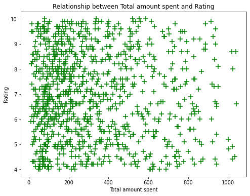

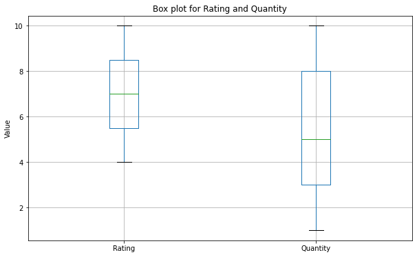

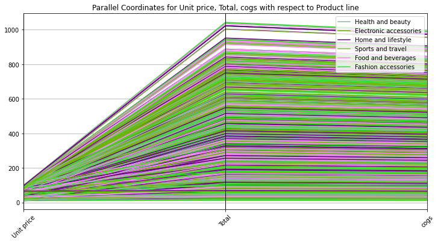

```python
import pandas as pd
import matplotlib.pyplot as plt

# Task 1: Load the dataset into a pandas DataFrame and read first 8 rows
df = pd.read_csv('https://raw.githubusercontent.com/patelmanishv/Sem4Data/main/Data/supermarket_sales%20-%20Sheet1.csv')
print("First 8 rows of the dataset:")
print(df.head(8))

# Task 2: Check for missing values and fill them with mean values of that column if any
print("\nChecking for missing values:")
print(df.isnull().sum())  # Check missing values
df.fillna(df.mean(), inplace=True)  # Fill missing values with mean

# Task 3: Find the number of orders with Quantity less than 3 and (Rating > 8.5 or Total > 600)
filtered_orders = df[(df['Quantity'] < 3) & ((df['Rating'] > 8.5) | (df['Total'] > 600))]
num_filtered_orders = len(filtered_orders)
print(f"\nNumber of orders with Quantity < 3 and (Rating > 8.5 or Total > 600): {num_filtered_orders}")

# Task 4: Find the sum of Total purchasing price spent by Member and Normal 'Customer type'
sum_total_by_type = df.groupby('Customer type')['Total'].sum()
print("\nTotal purchasing price spent by Member and Normal Customer type:")
print(sum_total_by_type)

# Task 5: Find the percentage of total gross income based on different Payment methods
payment_gross_income = df.groupby('Payment')['gross income'].sum()
total_gross_income = df['gross income'].sum()
payment_percentage = (payment_gross_income / total_gross_income) * 100
print("\nPercentage of total gross income based on Payment methods:")
print(payment_percentage)

# Task 6: Analyze purchasing behavior of male and female customers and find their average purchase prices
gender_avg_purchase = df.groupby('Gender')['Total'].mean()
print("\nAverage purchase prices based on Gender:")
print(gender_avg_purchase)

# Task 7: Create a scatter plot showing the relationship between Total amount spent and Rating
plt.figure(figsize=(8, 6))
plt.scatter(df['Total'], df['Rating'], marker='+', s=100, color='green')
plt.xlabel('Total amount spent')
plt.ylabel('Rating')
plt.title('Relationship between Total amount spent and Rating')
plt.show()

# Task 8: Create a box plot for Rating and Quantity columns
plt.figure(figsize=(10, 6))
df.boxplot(column=['Rating', 'Quantity'])
plt.title('Box plot for Rating and Quantity')
plt.ylabel('Value')
plt.show()

# Task 9: Visualize with parallel coordinates for 'Unit price', 'Total', 'cogs' with respect to 'Product line'
from pandas.plotting import parallel_coordinates
plt.figure(figsize=(12, 6))
parallel_coordinates(df[['Product line', 'Unit price', 'Total', 'cogs']], 'Product line')
plt.title('Parallel Coordinates for Unit price, Total, cogs with respect to Product line')
plt.xticks(rotation=45)
plt.show()
```

## 88 “Use the file data.csv which contains 169 rows and 4 columns.

1. Convert this file into pandas Data Frame and Display basic statistics like mean, std, quartiles, etc. for this data frame.
2. Create a correlation table for the data frame and comment about what kind of correlation is there between Duration and Calories?
3. Find whether there any null or NA values, drop all such rows if found in the data frame and print the shape of the data frame after dropping.
4. Prepare a scatter matrix for the following data frame and prepare a parallel coordinates for Duration v/s Pulse, Maxpulse and Calories (all 3 other columns).
5. Do Maxpulse have any outliers? Find using function.
6. Show the outliers using box plot for Maxpulse, width of box plot should be 0.75 and notch should be True.
7. Create a scatter plot for Duration (x-axis) and then Pulse, Maxpulse and Calories (y-axis) with different colors. For each there should be different color and marker. ”

```
Basic statistics for the data frame:
         Duration       Pulse    Maxpulse     Calories
count  169.000000  169.000000  169.000000   164.000000
mean    63.846154  107.461538  134.047337   375.790244
std     42.299949   14.510259   16.450434   266.379919
min     15.000000   80.000000  100.000000    50.300000
25%     45.000000  100.000000  124.000000   250.925000
50%     60.000000  105.000000  131.000000   318.600000
75%     60.000000  111.000000  141.000000   387.600000
max    300.000000  159.000000  184.000000  1860.400000

Correlation table:
          Duration     Pulse  Maxpulse  Calories
Duration  1.000000 -0.155408  0.009403  0.922717
Pulse    -0.155408  1.000000  0.786535  0.025121
Maxpulse  0.009403  0.786535  1.000000  0.203813
Calories  0.922717  0.025121  0.203813  1.000000

Checking for null or NA values:
Duration    0
Pulse       0
Maxpulse    0
Calories    5
dtype: int64

Shape of data frame after dropping null values: (164, 4)

Outliers in Maxpulse column:
3      175
54     175
58     172
80     182
109    184
Name: Maxpulse, dtype: int64
```

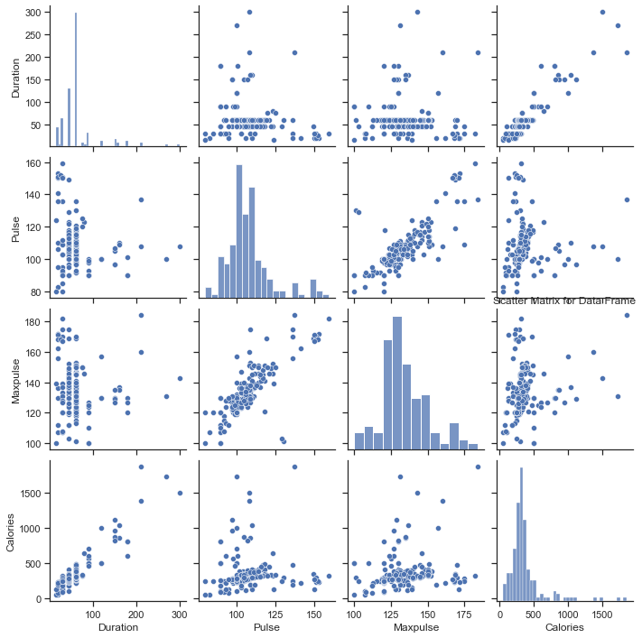

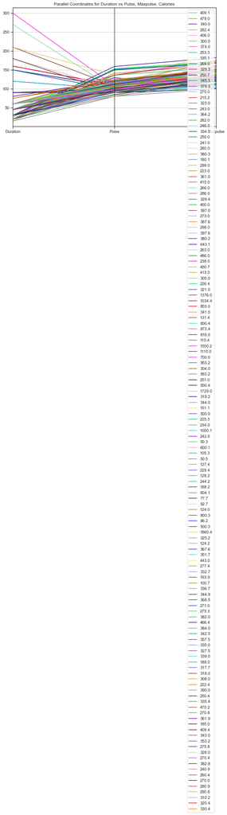

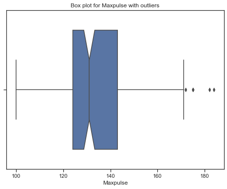

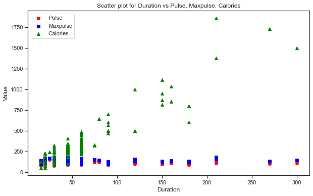

```python
import pandas as pd
import seaborn as sns
import matplotlib.pyplot as plt

# Task 1: Convert the file into pandas DataFrame and display basic statistics
df = pd.read_csv('https://raw.githubusercontent.com/patelmanishv/Sem4Data/main/Data/data.csv')
print("Basic statistics for the data frame:")
print(df.describe())

# Task 2: Create a correlation table for the data frame
correlation_table = df.corr()
print("\nCorrelation table:")
print(correlation_table)
# Comment on correlation between Duration and Calories
# Positive correlation between Duration and Calories indicates that as Duration increases, Calories also tend to increase.

# Task 3: Check for null or NA values, drop rows with null values, and print the shape
print("\nChecking for null or NA values:")
print(df.isnull().sum())  # Check for null values
df.dropna(inplace=True)  # Drop rows with null values
print("\nShape of data frame after dropping null values:", df.shape)

# Task 4: Prepare scatter matrix and parallel coordinates plot
sns.pairplot(df)
plt.title('Scatter Matrix for Data Frame')
plt.show()

plt.figure(figsize=(10, 6))
sns.set(style="ticks")
pd.plotting.parallel_coordinates(df[['Duration', 'Pulse', 'Maxpulse', 'Calories']], 'Calories')
plt.title('Parallel Coordinates for Duration vs Pulse, Maxpulse, Calories')
plt.show()

# Task 5: Check for outliers in Maxpulse column
def find_outliers(data):
    Q1 = data.quantile(0.25)
    Q3 = data.quantile(0.75)
    IQR = Q3 - Q1
    lower_bound = Q1 - 1.5 * IQR
    upper_bound = Q3 + 1.5 * IQR
    outliers = data[(data < lower_bound) | (data > upper_bound)]
    return outliers

outliers_maxpulse = find_outliers(df['Maxpulse'])
if not outliers_maxpulse.empty:
    print("\nOutliers in Maxpulse column:")
    print(outliers_maxpulse)
else:
    print("\nNo outliers found in Maxpulse column.")

# Task 6: Show outliers using box plot for Maxpulse
plt.figure(figsize=(8, 6))
sns.boxplot(x='Maxpulse', data=df, width=0.75, notch=True)
plt.title('Box plot for Maxpulse with outliers')
plt.show()

# Task 7: Create a scatter plot for Duration vs Pulse, Maxpulse, Calories
plt.figure(figsize=(10, 6))
plt.scatter(df['Duration'], df['Pulse'], color='red', label='Pulse', marker='o')
plt.scatter(df['Duration'], df['Maxpulse'], color='blue', label='Maxpulse', marker='s')
plt.scatter(df['Duration'], df['Calories'], color='green', label='Calories', marker='^')
plt.xlabel('Duration')
plt.ylabel('Value')
plt.title('Scatter plot for Duration vs Pulse, Maxpulse, Calories')
plt.legend()
plt.show()
```

## 89 The dataset provided in ‘kc_house_data.csv’ contains house sale prices for King County, which includes Seattle. It includes homes sold between May 2014 and May 2015.

```
"Perform the following tasks :
```

1. Load the csv to a dataframe named ‘house_survey’.
2. Display the first 5 rows of the dataframe.
3. Display the data types of each column.
4. Obtain a statistical summary of the dataframe.
5. Drop the columns ““id”” and ““Unnamed: 0””
6. Check all the null values present in all the columns of the dataframe.
7. Replace the missing values of the column ‘bedrooms’ with the mean of the column.
8. Replace the missing values of the column ‘bathrooms’ with the mean of the column.
9. Count the number of houses with unique floor values.
10. Using boxplot determine whether houses with a waterfront view or without a waterfront view have more price outliers. (Mention your answer as comment in the next cell)
11. Use the function regplot in the seaborn library to determine if the feature sqft_above is negatively or positively correlated with price. (Mention your answer as comment in the next cell).
12. Find the feature other than price that is most correlated with price. (Mention your answer as comment in the next cell).”

```
           id             date     price  bedrooms  bathrooms  sqft_living  \
0  7129300520  20141013T000000  221900.0         3       1.00         1180
1  6414100192  20141209T000000  538000.0         3       2.25         2570
2  5631500400  20150225T000000  180000.0         2       1.00          770
3  2487200875  20141209T000000  604000.0         4       3.00         1960
4  1954400510  20150218T000000  510000.0         3       2.00         1680

   sqft_lot  floors  waterfront  view  ...  grade  sqft_above  sqft_basement  \
0      5650     1.0           0     0  ...      7      1180.0              0
1      7242     2.0           0     0  ...      7      2170.0            400
2     10000     1.0           0     0  ...      6       770.0              0
3      5000     1.0           0     0  ...      7      1050.0            910
4      8080     1.0           0     0  ...      8      1680.0              0

   yr_built  yr_renovated  zipcode      lat     long  sqft_living15  \
0      1955             0    98178  47.5112 -122.257           1340
1      1951          1991    98125  47.7210 -122.319           1690
2      1933             0    98028  47.7379 -122.233           2720
3      1965             0    98136  47.5208 -122.393           1360
4      1987             0    98074  47.6168 -122.045           1800

   sqft_lot15
0        5650
1        7639
2        8062
3        5000
4        7503

[5 rows x 21 columns]
id                 int64
date              object
price            float64
bedrooms           int64
bathrooms        float64
sqft_living        int64
sqft_lot           int64
floors           float64
waterfront         int64
view               int64
condition          int64
```

[output cut: 58 more lines]

```
view             0
condition        0
grade            0
sqft_above       2
sqft_basement    0
yr_built         0
yr_renovated     0
zipcode          0
lat              0
long             0
sqft_living15    0
sqft_lot15       0
dtype: int64
Number of houses with unique floor values: 6
Feature most correlated with price (other than price itself): sqft_living
```

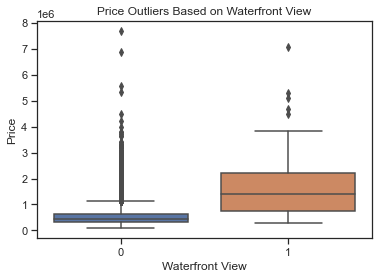

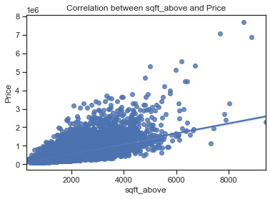

```python
import pandas as pd
import seaborn as sns
import matplotlib.pyplot as plt

# Task 1: Load the CSV into a DataFrame named 'house_survey'
house_survey = pd.read_csv('kc_house_data.csv')

# Task 2: Display the first 5 rows of the dataframe
print(house_survey.head())

# Task 3: Display the data types of each column
print(house_survey.dtypes)

# Task 4: Obtain a statistical summary of the dataframe
print(house_survey.describe())

# Task 5: Drop the column "id"
house_survey.drop(['id'], axis=1, inplace=True)

# Task 6: Check all the null values present in all the columns of the dataframe
print(house_survey.isnull().sum())

# Task 7: Replace the missing values of the column 'bedrooms' with the mean of the column
house_survey['bedrooms'].fillna(house_survey['bedrooms'].mean(), inplace=True)

# Task 8: Replace the missing values of the column 'bathrooms' with the mean of the column
house_survey['bathrooms'].fillna(house_survey['bathrooms'].mean(), inplace=True)

# Task 9: Count the number of houses with unique floor values
unique_floors_count = house_survey['floors'].nunique()
print("Number of houses with unique floor values:", unique_floors_count)

# Task 10: Determine whether houses with a waterfront view or without a waterfront view have more price outliers using boxplot
sns.boxplot(x='waterfront', y='price', data=house_survey)
plt.title("Price Outliers Based on Waterfront View")
plt.xlabel("Waterfront View")
plt.ylabel("Price")
plt.show()

# Task 11: Determine if the feature sqft_above is negatively or positively correlated with price using regplot
sns.regplot(x='sqft_above', y='price', data=house_survey)
plt.title("Correlation between sqft_above and Price")
plt.xlabel("sqft_above")
plt.ylabel("Price")
plt.show()

# Task 12: Find the feature other than price that is most correlated with price
correlation_matrix = house_survey.corr()
correlation_with_price = correlation_matrix['price'].sort_values(ascending=False)
print("Feature most correlated with price (other than price itself):", correlation_with_price.index[1])  # Index 0 is price itself
```

## 90 “For the given dataset – iris.csv, perform following exploratory data analysis using python -

```
Use comment feature to answer appropriate questions –

a) Load dataset into jupyter notebook using appropriate libraries. Check the datatypes of the dataset attributes. Does the data contain any missing /null values?
b) Extract head and tail of the dataset using appropriate methods.
c) Summarize statistical figures (i.e. mean, median, percentiles) in one table using appropriate method.
d) Create correlation table of all variables. What can you infer about relation between petal length and sepal length?
e) Create parallel coordinate plot of iris dataset. What can you infer about petal length and petal width?
f) Create box plot of sepal width. Visualizing the plot, answer whether the sepal width data contains any outliers.
g) Create cross tabulation of sepal length and petal width attributes. What does the table represent?
h) Create scatter matrix of the dataset.
i) Create a new column called ‘SepalLengthSize’ which contains “High” if sepal length ≥ 5 or “Low” if sepal length < 5.
"
```

```
Data types of dataset attributes:
Id                 int64
SepalLengthCm    float64
SepalWidthCm     float64
PetalLengthCm    float64
PetalWidthCm     float64
Species           object
dtype: object

Missing/null values in dataset:
Id               0
SepalLengthCm    0
SepalWidthCm     0
PetalLengthCm    0
PetalWidthCm     0
Species          0
dtype: int64

Head of the dataset:
   Id  SepalLengthCm  SepalWidthCm  PetalLengthCm  PetalWidthCm      Species
0   1            5.1           3.5            1.4           0.2  Iris-setosa
1   2            4.9           3.0            1.4           0.2  Iris-setosa
2   3            4.7           3.2            1.3           0.2  Iris-setosa
3   4            4.6           3.1            1.5           0.2  Iris-setosa
4   5            5.0           3.6            1.4           0.2  Iris-setosa

Tail of the dataset:
      Id  SepalLengthCm  SepalWidthCm  PetalLengthCm  PetalWidthCm  \
145  146            6.7           3.0            5.2           2.3
146  147            6.3           2.5            5.0           1.9
147  148            6.5           3.0            5.2           2.0
148  149            6.2           3.4            5.4           2.3
149  150            5.9           3.0            5.1           1.8

            Species
145  Iris-virginica
146  Iris-virginica
147  Iris-virginica
148  Iris-virginica
149  Iris-virginica
```

[output cut: 105 more lines]

```

New column 'SepalLengthSize' added:
   Id  SepalLengthCm  SepalWidthCm  PetalLengthCm  PetalWidthCm      Species  \
0   1            5.1           3.5            1.4           0.2  Iris-setosa
1   2            4.9           3.0            1.4           0.2  Iris-setosa
2   3            4.7           3.2            1.3           0.2  Iris-setosa
3   4            4.6           3.1            1.5           0.2  Iris-setosa
4   5            5.0           3.6            1.4           0.2  Iris-setosa

  SepalLengthSize
0            High
1             Low
2             Low
3             Low
4            High
```

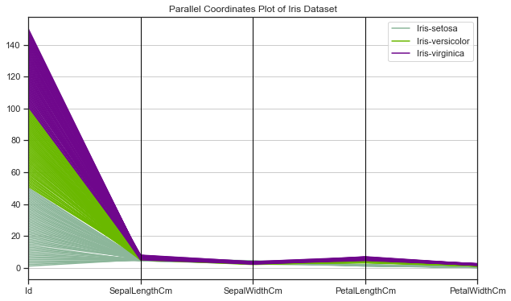

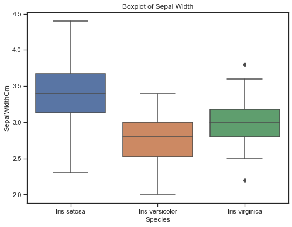

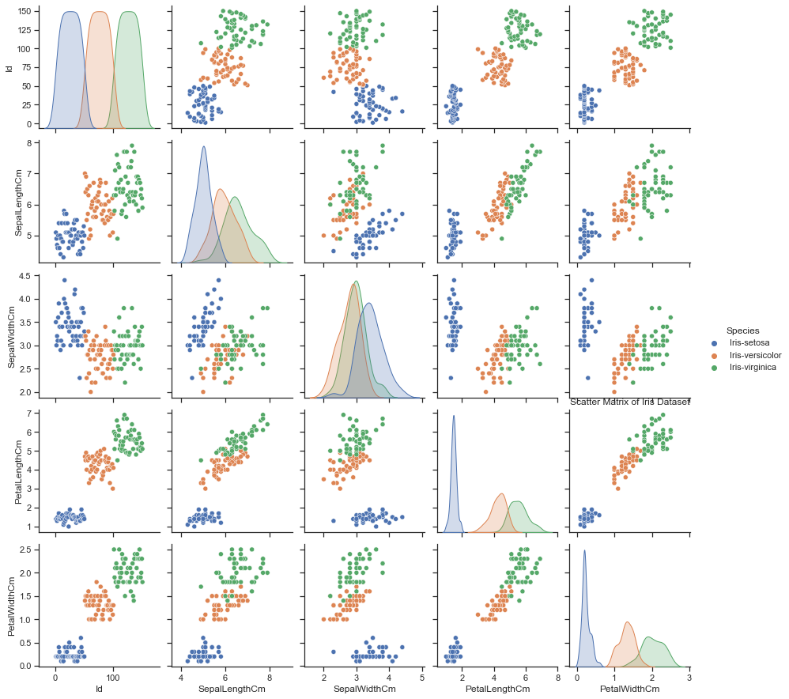

```python
import pandas as pd
import seaborn as sns
import matplotlib.pyplot as plt

# a) Load dataset and check datatypes, missing/null values
iris_df = pd.read_csv('https://raw.githubusercontent.com/patelmanishv/Sem4Data/main/Data/iris.csv')
print("Data types of dataset attributes:")
print(iris_df.dtypes)
print("\nMissing/null values in dataset:")
print(iris_df.isnull().sum())

# b) Extract head and tail of the dataset
print("\nHead of the dataset:")
print(iris_df.head())
print("\nTail of the dataset:")
print(iris_df.tail())

# c) Summarize statistical figures in one table
stat_summary = iris_df.describe()
print("\nStatistical summary:")
print(stat_summary)

# d) Create correlation table of all variables
correlation_matrix = iris_df.corr()
print("\nCorrelation table:")
print(correlation_matrix)
# Inference about relation between petal length and sepal length:
# Positive correlation between petal length and sepal length indicates that as petal length increases, sepal length tends to increase as well.

# e) Create parallel coordinate plot of iris dataset
plt.figure(figsize=(10, 6))
sns.set(style="ticks")
pd.plotting.parallel_coordinates(iris_df, class_column='Species')
plt.title('Parallel Coordinates Plot of Iris Dataset')
plt.show()
# Inference about petal length and petal width:
# Different species can be distinguished based on the relationship between petal length and petal width.

# f) Create box plot of sepal width to check for outliers
plt.figure(figsize=(8, 6))
sns.boxplot(x='Species', y='SepalWidthCm', data=iris_df)
plt.title('Boxplot of Sepal Width')
plt.show()
# Answer: Visualizing the plot, we can check if sepal width data contains any outliers.

# g) Create cross tabulation of sepal length and petal width attributes
cross_tab = pd.crosstab(iris_df['SepalLengthCm'], iris_df['PetalWidthCm'])
print("\nCross tabulation of Sepal Length and Petal Width:")
print(cross_tab)
# The table represents the count of occurrences for each combination of Sepal Length and Petal Width.

# h) Create scatter matrix of the dataset
sns.pairplot(iris_df, hue='Species')
plt.title('Scatter Matrix of Iris Dataset')
plt.show()

# i) Create a new column 'SepalLengthSize' based on sepal length
iris_df['SepalLengthSize'] = 'Low'
iris_df.loc[iris_df['SepalLengthCm'] >= 5, 'SepalLengthSize'] = 'High'
print("\nNew column 'SepalLengthSize' added:")
print(iris_df.head())
```